# Iris Analysis

Ale F. Benages

3/22/2021

# Libraries

```r
#install.packages('tidyverse')
#install.packages(readr)
library("readr")
library(ggplot2)
```

# Load CSV

```r
IrisDataset <- read.csv('iris.csv')
```

# 1. EDA

## 1.1 Knowing your data

```r
# To list the attributes of the data set.
attributes(IrisDataset)
```

```
## $names
## [1] "X"            "Sepal.Length" "Sepal.Width"  "Petal.Length" "Petal.Width"
## [6] "Species"
##
## $class
## [1] "data.frame"
##
## $row.names
##   [1]   1   2   3   4   5   6   7   8   9  10  11  12  13  14  15  16  17  18
##  [19]  19  20  21  22  23  24  25  26  27  28  29  30  31  32  33  34  35  36
##  [37]  37  38  39  40  41  42  43  44  45  46  47  48  49  50  51  52  53  54
##  [55]  55  56  57  58  59  60  61  62  63  64  65  66  67  68  69  70  71  72
##  [73]  73  74  75  76  77  78  79  80  81  82  83  84  85  86  87  88  89  90
##  [91]  91  92  93  94  95  96  97  98  99 100 101 102 103 104 105 106 107 108
## [109] 109 110 111 112 113 114 115 116 117 118 119 120 121 122 123 124 125 126
## [127] 127 128 129 130 131 132 133 134 135 136 137 138 139 140 141 142 143 144
## [145] 145 146 147 148 149 150
```

```r
# To print the min, max, mean, median, and quartiles of each attribute.
summary(IrisDataset)
```

```
##        X           Sepal.Length    Sepal.Width     Petal.Length
##  Min.   :  1.00   Min.   :4.300   Min.   :2.000   Min.   :1.000
##  1st Qu.: 38.25   1st Qu.:5.100   1st Qu.:2.800   1st Qu.:1.600
##  Median : 75.50   Median :5.800   Median :3.000   Median :4.350
##  Mean   : 75.50   Mean   :5.843   Mean   :3.057   Mean   :3.758
##  3rd Qu.:112.75   3rd Qu.:6.400   3rd Qu.:3.300   3rd Qu.:5.100
##  Max.   :150.00   Max.   :7.900   Max.   :4.400   Max.   :6.900
##   Petal.Width          Species
##  Min.   :0.100   setosa    :50
##  1st Qu.:0.300   versicolor:50
##  Median :1.300   virginica :50
##  Mean   :1.199
##  3rd Qu.:1.800
##  Max.   :2.500
```

```r
# To display the structure of your data set.
str(IrisDataset)
```

```
## 'data.frame':    150 obs. of  6 variables:
##  $ X           : int  1 2 3 4 5 6 7 8 9 10 ...
##  $ Sepal.Length: num  5.1 4.9 4.7 4.6 5 5.4 4.6 5 4.4 4.9 ...
##  $ Sepal.Width : num  3.5 3 3.2 3.1 3.6 3.9 3.4 3.4 2.9 3.1 ...
##  $ Petal.Length: num  1.4 1.4 1.3 1.5 1.4 1.7 1.4 1.5 1.4 1.5 ...
##  $ Petal.Width : num  0.2 0.2 0.2 0.2 0.2 0.4 0.3 0.2 0.2 0.1 ...
##  $ Species     : Factor w/ 3 levels "setosa","versicolor",..: 1 1 1 1 1 1 1 1 1 1 ...
```

```r
# To get th names of the attributes within your data set.
names(IrisDataset)
```

```
## [1] "X"            "Sepal.Length" "Sepal.Width"  "Petal.Length" "Petal.Width"
## [6] "Species"
```

As the analysis goal is about the relationship between the Petal Length and Petal Width, let’s analyze those variables detailed

```r
# specific info about the Petal.Lenght
summary(IrisDataset$Petal.Length)
```

```
##    Min. 1st Qu.  Median    Mean 3rd Qu.    Max.
##   1.000   1.600   4.350   3.758   5.100   6.900
```

```r
# specific info about the Petal.Width
summary(IrisDataset$Petal.Width)
```

```
##    Min. 1st Qu.  Median    Mean 3rd Qu.    Max.
##   0.100   0.300   1.300   1.199   1.800   2.500
```

## 1.2 Missing Values?

If there are, the summarye() will count how many NA’s you have.

```r
summary(IrisDataset)
```

```
##        X           Sepal.Length    Sepal.Width     Petal.Length
##  Min.   :  1.00   Min.   :4.300   Min.   :2.000   Min.   :1.000
##  1st Qu.: 38.25   1st Qu.:5.100   1st Qu.:2.800   1st Qu.:1.600
##  Median : 75.50   Median :5.800   Median :3.000   Median :4.350
##  Mean   : 75.50   Mean   :5.843   Mean   :3.057   Mean   :3.758
##  3rd Qu.:112.75   3rd Qu.:6.400   3rd Qu.:3.300   3rd Qu.:5.100
##  Max.   :150.00   Max.   :7.900   Max.   :4.400   Max.   :6.900
##   Petal.Width          Species
##  Min.   :0.100   setosa    :50
##  1st Qu.:0.300   versicolor:50
##  Median :1.300   virginica :50
##  Mean   :1.199
##  3rd Qu.:1.800
##  Max.   :2.500
```

Also you can show your NA’s through logical data. (TRUE if it’s missing, FALSE if it’s not.)

```r
is.na(IrisDataset)
```

[output not shown]

[output cut: 136 more lines]

Replace the missing values with the mean, which is common technique, but **something to use with care with as it can skew the data**.

```r
#DatasetName$ColumnName[is.na(DatasetName$ColumnName)]<-mean(DatasetName$ColumnName,na.rm = TRUE)
```

## 1.3 Some Plots

### PETAL’S LENGTH

[figure not shown]

```r
hist(IrisDataset$Petal.Length,
     main="Sepal Length distribution", xlab="Lenght [mm]",
     col='green')
```

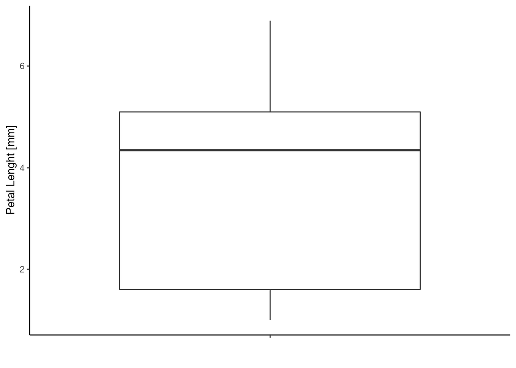

```r
#' boxplot
ggplot(data = IrisDataset, aes(x = "", y = Petal.Length)) +
  geom_boxplot() + theme_classic()+
  xlab("")+ylab("Petal Lenght [mm]")
```

In this case, Boxplot it’s not being very descriptive, let’s try a Violinplot:

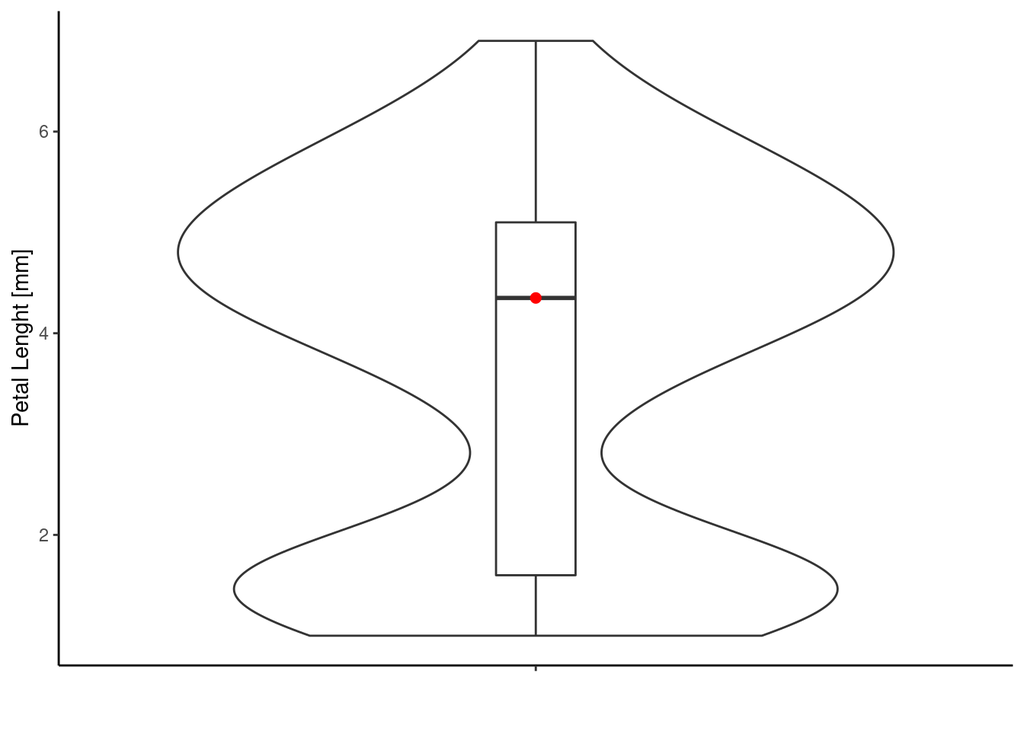

```r
#' violinplot
ggplot(data = IrisDataset, aes(x = "", y = Petal.Length)) +
  geom_violin() + theme_classic()+
  xlab("")+ylab("Petal Lenght [mm]")+
  geom_boxplot(width=0.1)+
  stat_summary(fun=median, geom="point", size=2, color="red")
```

### PETAL’S WIDTH

[figure not shown]

```r
hist(IrisDataset$Petal.Width,
     main="Sepal Length distribution", xlab="Lenght [mm]",
     col='violet')
```

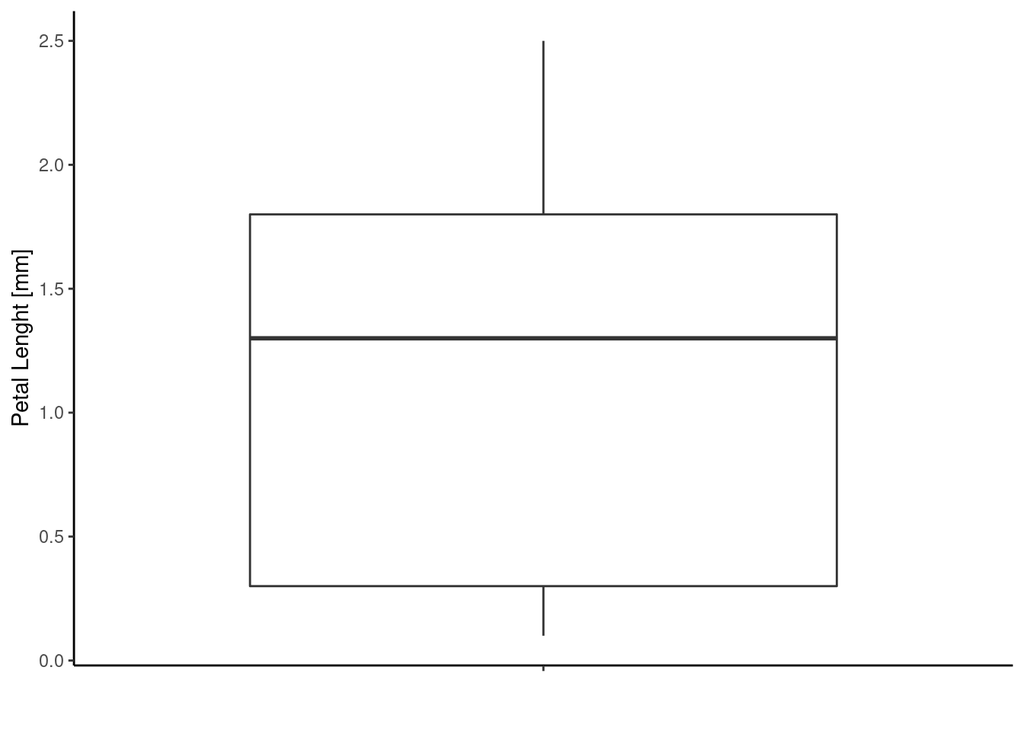

```r
#' boxplot
ggplot(data = IrisDataset, aes(x = "", y = Petal.Width)) +
  geom_boxplot() + theme_classic()+
  xlab("")+ylab("Petal Lenght [mm]")
```

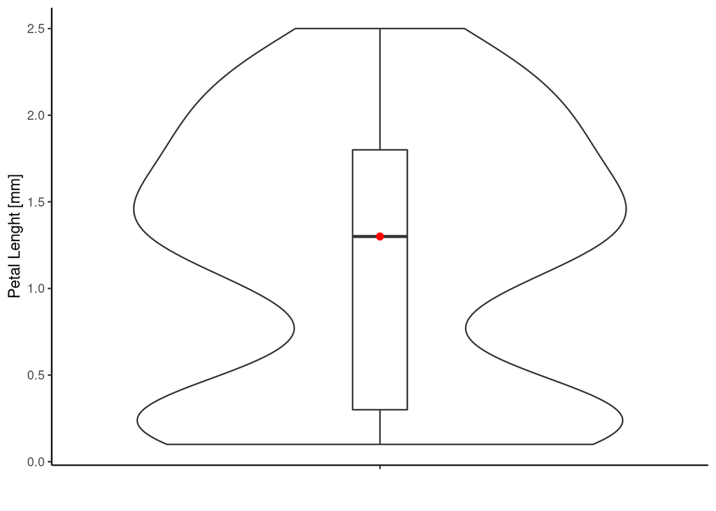

```r
#' violinplot
ggplot(data = IrisDataset, aes(x = "", y = Petal.Width)) +
  geom_violin() + theme_classic()+
  xlab("")+ylab("Petal Lenght [mm]")+
  geom_boxplot(width=0.1)+
  stat_summary(fun=median, geom="point", size=2, color="red")
```

### Petal’s Length vs Petal’s Width

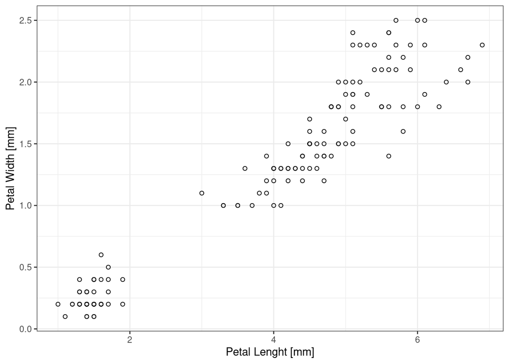

```r
ggplot(data = IrisDataset, aes(x = Petal.Length  , y = Petal.Width))  +
  geom_point(shape = 1) +
  xlab("Petal Lenght [mm]")+ylab("Petal Width [mm]") +
  theme_bw()
```

There is a positive correlation between those variables.

# 2. Testing and Training Sets

First of all, define a seed to get *reproducible experiments*.

```r
set.seed(122)
```

These two lines calculate the sizes of each set **but do not create** the sets:

```r
trainSize<-round(nrow(IrisDataset)*0.8) # 80/20%
testSize<-nrow(IrisDataset)-trainSize
```

Just to check the dimension of the empty vectors.

```r
print(trainSize)
```

```
## [1] 120
```

```r
print(testSize)
```

```
## [1] 30
```

So, how do you create the **train/test sets**?. We also want these sets to be in a randomized order, which will help to create an optimal model. To perform this, you need to run these three lines of code.

```r
training_indices<-sample(seq_len(nrow(IrisDataset)),size =trainSize)
trainSet<-IrisDataset[training_indices,]
testSet <-IrisDataset[-training_indices,]
```

# 3. Linear Regression

```r
# The basic line of code for the linear model function.
LinearModel<- lm(Petal.Width ~ Petal.Length, trainSet )
```

thats all!. Now to see the metrics of the model, just call **summary()**

```r
summary(LinearModel)
```

```
##
## Call:
## lm(formula = Petal.Width ~ Petal.Length, data = trainSet)
##
## Residuals:
##      Min       1Q   Median       3Q      Max
## -0.58080 -0.12159 -0.01985  0.12187  0.62881
##
## Coefficients:
##              Estimate Std. Error t value Pr(>|t|)
## (Intercept)  -0.36686    0.04356  -8.422 1.03e-13 ***
## Petal.Length  0.41922    0.01065  39.347  < 2e-16 ***
## ---
## Signif. codes:  0 '***' 0.001 '**' 0.01 '*' 0.05 '.' 0.1 ' ' 1
##
## Residual standard error: 0.2065 on 118 degrees of freedom
## Multiple R-squared:  0.9292, Adjusted R-squared:  0.9286
## F-statistic:  1548 on 1 and 118 DF,  p-value: < 2.2e-16
```

## 3.1 Predictions

To make predictions, we use the **Test Set**.

```r
prediction <- predict(LinearModel, testSet)
prediction
```

```
##         8         9        22        25        26        30        36        39
## 0.2619787 0.2200562 0.2619787 0.4296684 0.3039011 0.3039011 0.1362113 0.1781338
##        59        65        68        69        78        80        84        88
## 1.5615743 1.1423499 1.3519621 1.5196519 1.7292641 1.1004275 1.7711865 1.4777294
##        92        93       106       107       111       113       114       125
## 1.5615743 1.3100397 2.4000231 1.5196519 1.7711865 1.9388763 1.7292641 2.0227212
##       127       130       131       132       149       150
## 1.6454192 2.0646436 2.1904109 2.3161782 1.8969538 1.7711865
```